# Modelos lineales. Ejercicios de la unidad 1

Alex Sánchez y Francesc Carmona

14 de Febrero de 2023

[figure not shown]

[figure not shown]

```r
> if(!(require(compareGroups))) install.packages("compareGroups")
> if(!(require(faraway))) install.packages("faraway")
> if(!(require(GGally))) install.packages("GGally")
> if(!(require(devtools))) install.packages("devtools")
> if(!(require(rootSolve))) install.packages("rootSolve")
> if(!(require(mosaicCalc))) install.packages("mosaicCalc")
> if(!(require(printr))) {
+   install.packages('printr',
+             type = 'source',
+             repos = c('http://yihui.name/xran', 'http://cran.rstudio.com')
+   )
+ }
```

# Ejercicios iniciales

### Ejercicio 1

Los datos de los buitres leonados son:

```r
> heartbpm <- c(47.53, 48.27, 49.51, 51.09, 52.57, 54.30,
+               54.25, 54.45, 57.95, 60.92, 61.91, 77.92,
+               82.07, 82.95, 83.94, 86.96, 90.42, 92.93, 100.05)
> metabol <- c(6.15, 6.31, 6.43, 6.78, 6.86, 6.90, 7.37, 7.41,
+              8.24, 9.22, 8.16, 12.61, 15.26, 13.09, 14.59,
+              17.35, 18.57, 19.00, 20.70)
> vulture <- data.frame(heartbpm, metabol)
> rm(heartbpm, metabol)
> attach(vulture)
```

#### Apartado (a)

El gráfico de dispersión se consigue así:

```r
> plot(heartbpm, metabol, ylim=c(0,30),
+        main="Griffon vulture, 1999-05-17",
+        xlab="heart beats (per minute)",
+        ylab="metabolic rate [J/(g*h)]")
```

#### Apartado (b)

La recta de regresión se calcula con la función `lm()` y se añade al gráfico de dispersión con la función `abline()`.

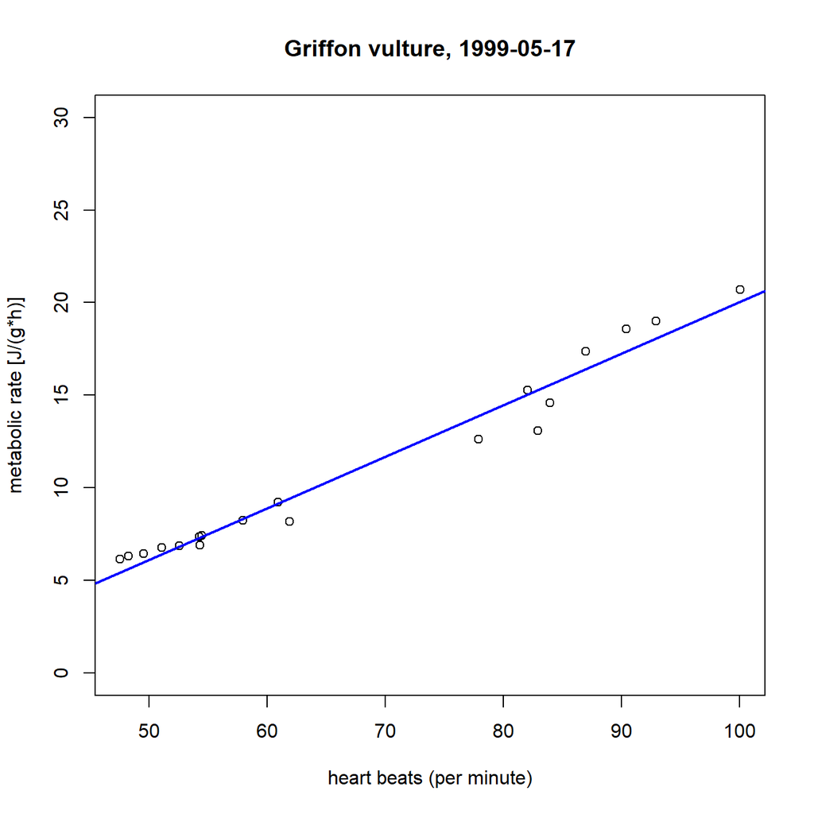

```r
> mod <- lm(metabol ~ heartbpm, data=vulture)
> abline(mod, lwd=2, col="blue")
```

#### Apartado (c)

El gráfico de los residuos es

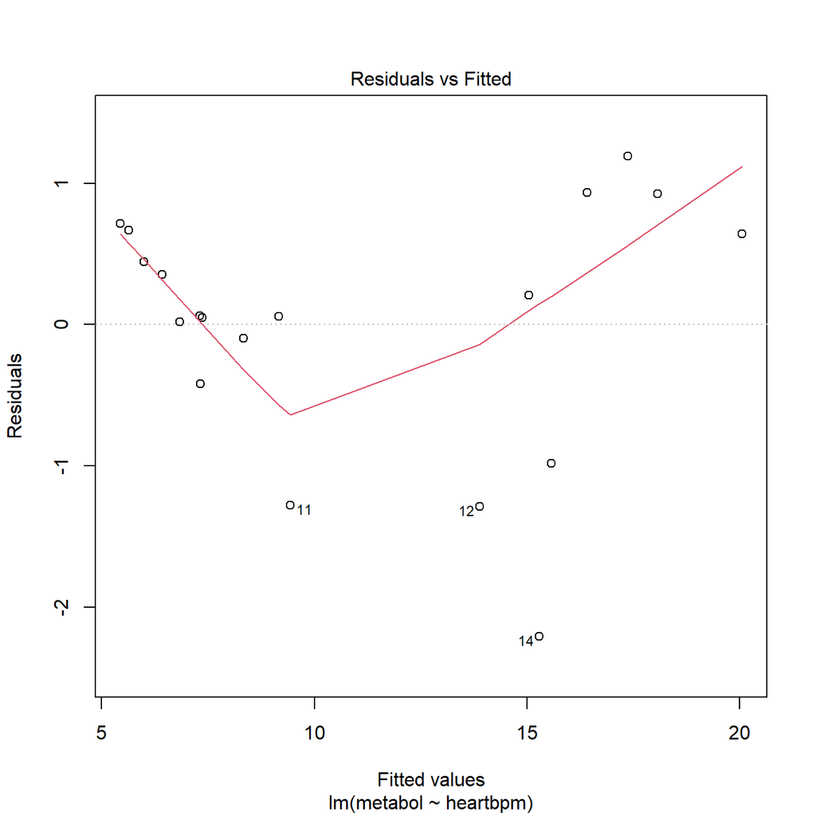

```r
> plot(mod, which=1)
```

La instrucción `plot()` aplicada a un objeto `lm` proporciona 4 gráficos sobre los residuos. Ahora nos interesa únicamente el 1.

#### Apartado (d)

Para dibujar la regresión parabólica sobre el gráfico de dispersión lo podemos hacer así

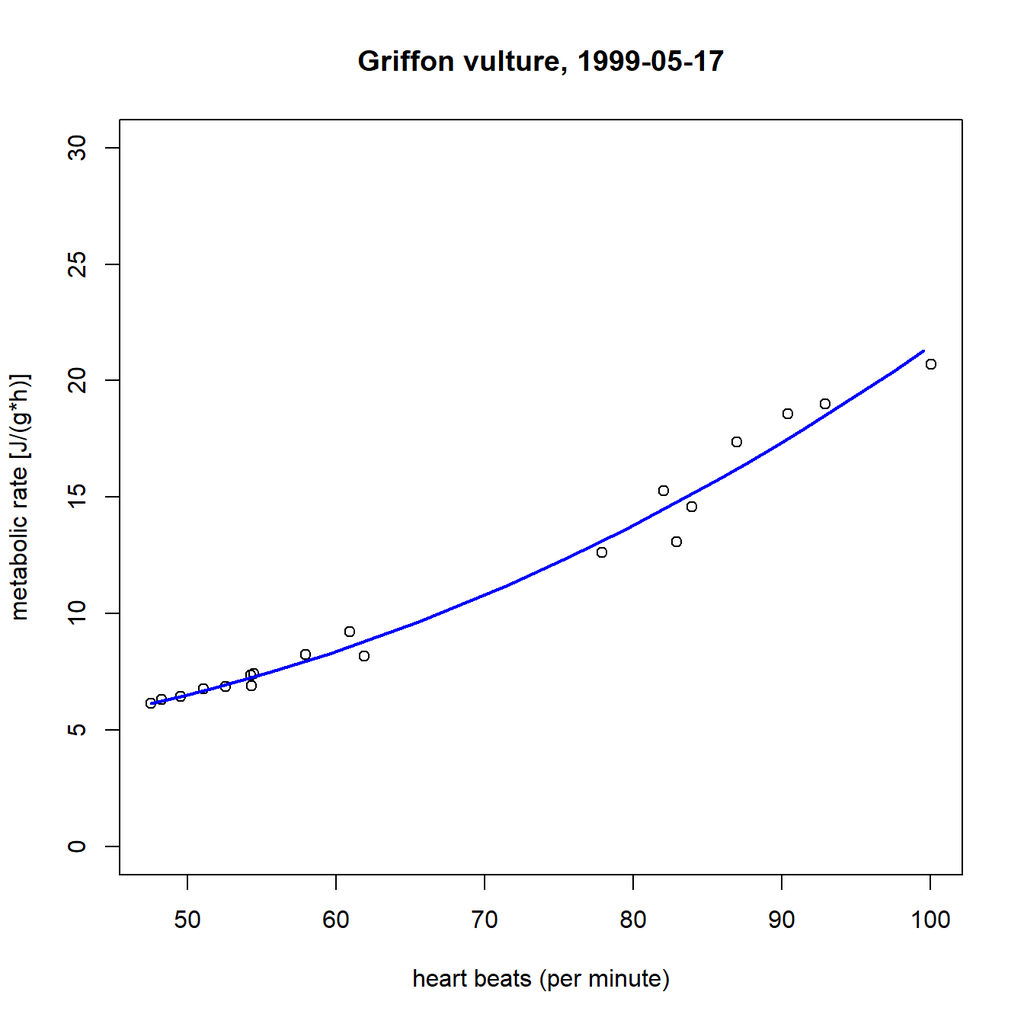

```r
> mod2 <- lm(metabol ~ heartbpm + I(heartbpm^2), data=vulture)
> x <- seq(min(heartbpm), max(heartbpm), by=2)
> y <- predict(mod2, newdata=data.frame(heartbpm=x))
> plot(heartbpm, metabol, ylim=c(0,30),
+        main="Griffon vulture, 1999-05-17",
+        xlab="heart beats (per minute)",
+        ylab="metabolic rate [J/(g*h)]")
> lines(x,y, lwd=2, col="blue")
```

El mismo resultado se puede obtener con la función `curve()`.

```r
> cc <- coef(mod2)
> curve(cc[1] + cc[2]*x + cc[3] * x^2,
+       from=min(heartbpm), to=max(heartbpm),
+       lwd=2, col="blue", add=TRUE)
```

### Ejercicio 2

Vamos a utilizar el paquete `XML` para leer los datos directamente de la página web (*scraping*).

```r
> library(XML)   # En Ubuntu hay que instalar el paquete libxml2-dev
> library(RCurl) # for getURL()
> url <- "https://www.fisterra.com/formacion/metodologia-investigacion/tecnicas-regresion-regresion-lineal-simple/"
> html <- getURL(url)
> tbls_xml <- readHTMLTable(html, stringsAsFactors = FALSE)
> typeof(tbls_xml)
```

```
[1] "list"
```

```r
> length(tbls_xml)
```

```
[1] 27
```

De las 27 tablas hay que buscar cual es la que nos interesa (la 2).

```r
> datos <- readHTMLTable(html, which=2, header=F, skip.rows = 1,
+                        colClasses = rep("integer", 6))
> head(datos)
```

| V1 | V2 | V3 | V4 | V5 | V6 |
| --- | --- | --- | --- | --- | --- |
| 1 | 114 | 17 | 36 | 156 | 47 |
| 2 | 134 | 18 | 37 | 159 | 47 |
| 3 | 124 | 19 | 38 | 130 | 48 |
| 4 | 128 | 19 | 39 | 157 | 48 |
| 5 | 116 | 20 | 40 | 142 | 50 |
| 6 | 120 | 21 | 41 | 144 | 50 |

```r
> colnames(datos) <- c("num","tas","edad","num","tas","edad")
> datos <- rbind(datos[,1:3],datos[,4:6])
> datos <- datos[-70,]
> str(datos)
```

```
'data.frame':   69 obs. of  3 variables:
 $ num : int  1 2 3 4 5 6 7 8 9 10 ...
 $ tas : int  114 134 124 128 116 120 138 130 139 125 ...
 $ edad: int  17 18 19 19 20 21 21 22 23 25 ...
```

Con estos datos ya podemos calcular la recta de regresión.

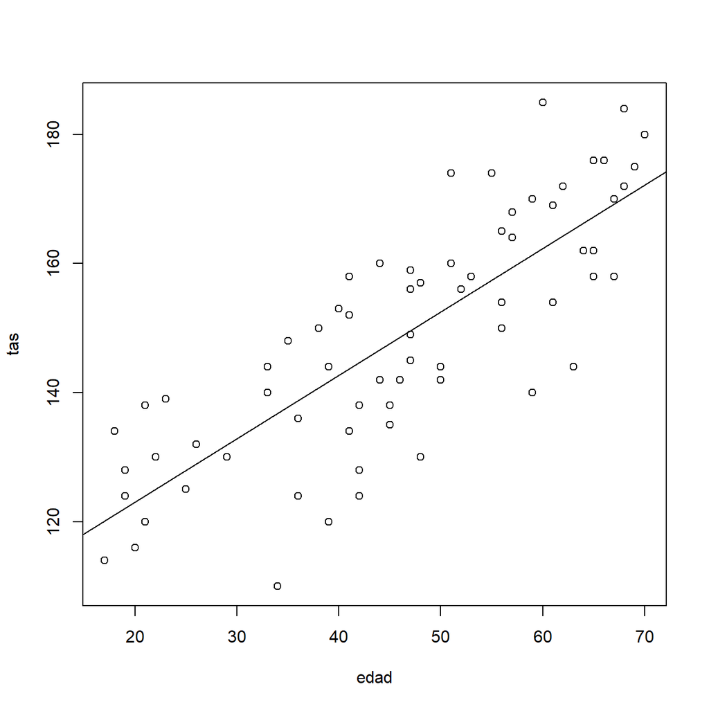

```r
> attach(datos)
> fit <- lm(tas ~ edad, data=datos)
> plot(edad,tas)
> abline(fit)
```

```r
> summary(fit)
```

```
Call:
lm(formula = tas ~ edad, data = datos)

Residuals:
    Min      1Q  Median      3Q     Max
-26.794  -7.024   1.960   8.190  22.634

Coefficients:
            Estimate Std. Error t value Pr(>|t|)
(Intercept) 103.3527     4.3261   23.89   <2e-16 ***
edad          0.9836     0.0892   11.03   <2e-16 ***
---
Signif. codes:  0 '***' 0.001 '**' 0.01 '*' 0.05 '.' 0.1 ' ' 1

Residual standard error: 11.09 on 67 degrees of freedom
Multiple R-squared:  0.6447,    Adjusted R-squared:  0.6394
F-statistic: 121.6 on 1 and 67 DF,  p-value: < 2.2e-16
```

```r
> coef(fit)
```

```
(Intercept)        edad
103.3526585   0.9835585
```

# Ejercicios del libro de Faraway

## Capítulo 1

Los ejercicios de este capítulo tienen todos la misma estructura. Para resolverlos empezaremos informándonos sobre los datos a analizar. Observad que utilizando el paquete `printr` en combinación con `Rmarkdown` y `knitr` es posible obtener fácilmente una impresión de la ayuda, así como un formateo agradable y rápido de las tablas. La impresión de la ayuda se ha eliminado para evitar conflictos con el menú.

A continuación comprobaremos el tipo de cada columna. Si hay variables que deberían ser factores pero aparecen como numéricas las transformaremos en factores.

Finalmente realizaremos un análisis descriptivo univariante y bivariante.

Naturalmente ésto puede hacerse de diversas formas. La que se propone aquí no es más que una que busca un equilibrio entre la calidad y el tiempo, para lo que hemos utilizado dos paquetes, `compareGroups` y `GGally` que simplifcan dichos análisis.

### Ejercicio 1

**The dataset `teengamb` concerns a study of teenage gambling in Britain. Make a numerical and graphical summary of the data, commenting on any features that you find interesting. Limit the output you present to a quantity that a busy reader would find sufficient to get a basic understanding of the data.**

```r
> require(faraway)
> require(printr)
> data(teengamb, package = "faraway")
> ??teengamb
```

| Package | Topic | Title |
| --- | --- | --- |
| faraway | teengamb | Study of teenage gambling in Britain |

```r
> head(teengamb)
```

| sex | status | income | verbal | gamble |
| --- | --- | --- | --- | --- |
| 1 | 51 | 2.00 | 8 | 0.0 |
| 1 | 28 | 2.50 | 8 | 0.0 |
| 1 | 37 | 2.00 | 6 | 0.0 |
| 1 | 28 | 7.00 | 4 | 7.3 |
| 1 | 65 | 2.00 | 8 | 19.6 |
| 1 | 61 | 3.47 | 6 | 0.1 |

```r
> str(teengamb)
```

```
'data.frame':   47 obs. of  5 variables:
 $ sex   : int  1 1 1 1 1 1 1 1 1 1 ...
 $ status: int  51 28 37 28 65 61 28 27 43 18 ...
 $ income: num  2 2.5 2 7 2 3.47 5.5 6.42 2 6 ...
 $ verbal: int  8 8 6 4 8 6 7 5 6 7 ...
 $ gamble: num  0 0 0 7.3 19.6 0.1 1.45 6.6 1.7 0.1 ...
```

```r
> apply(teengamb, 2, class)
```

```
      sex    status    income    verbal    gamble
"numeric" "numeric" "numeric" "numeric" "numeric"
```

```r
> teengamb$sex <- factor(teengamb$sex, labels = c("male","female"))
> teengamb$verbal <- factor(teengamb$verbal)
```

```r
> require(compareGroups)
> res <- compareGroups(~., data = teengamb)
> restab <- createTable(res)
> restab
```

```
--------Summary descriptives table ---------

_________________________
              [ALL]    N
              N=47
¯¯¯¯¯¯¯¯¯¯¯¯¯¯¯¯¯¯¯¯¯¯¯¯¯
sex:                   47
    male   28 (59.6%)
    female 19 (40.4%)
status     45.2 (17.3) 47
income     4.64 (3.55) 47
verbal:                47
    1       1 (2.13%)
    2       1 (2.13%)
    4       4 (8.51%)
    5       3 (6.38%)
    6      12 (25.5%)
    7       9 (19.1%)
    8      10 (21.3%)
    9       6 (12.8%)
    10      1 (2.13%)
gamble     19.3 (31.5) 47
¯¯¯¯¯¯¯¯¯¯¯¯¯¯¯¯¯¯¯¯¯¯¯¯¯
```

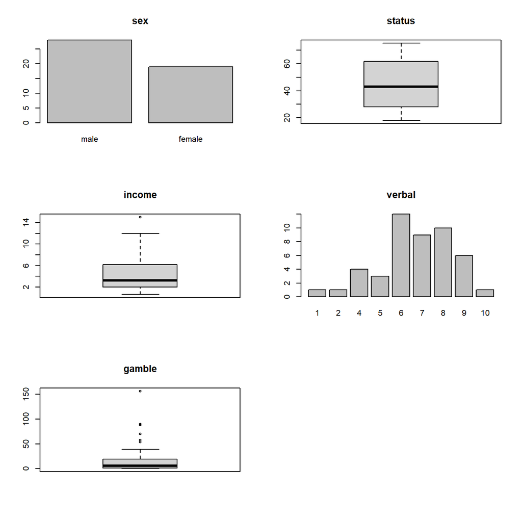

```r
> par(mfrow = c(3,2))
> for (i in 1:dim(teengamb)[2]) {
+   if (class(teengamb[,i]) == "factor")
+     {try(plot(teengamb[,i],main = colnames(teengamb)[i]),TRUE)
+   }else
+     {try(boxplot(teengamb[,i],main = colnames(teengamb)[i]),TRUE)
+   }
+ }
```

Podemos hacer el análisis descriptivo bivariante separando factores de variables numéricas o bien utilizar el paquete “GGally” que facilita el análisis con una sola instrucción.

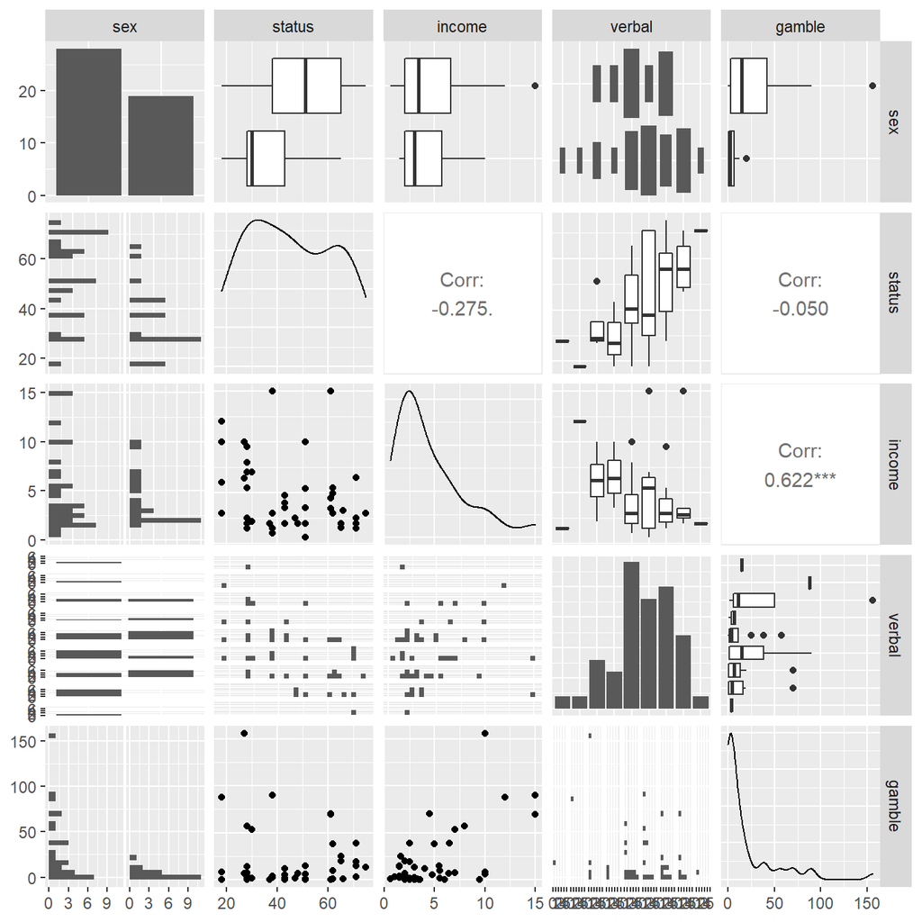

```r
> require(ggplot2)
> require(GGally)
> ggpairs(teengamb)
```

### Ejercicio 2

**The dataset uswages is drawn as a sample from the Current Population Survey in 1988. Make a numerical and graphical summary of the data as in the previous question.**

```r
> data("uswages",package = "faraway")
> ??uswages
```

| Package | Topic | Title |
| --- | --- | --- |
| faraway | uswages | Weekly wages of US male workers in 1988 |
| HistData | DrinksWages | Elderton and Pearson’s (1910) data on drinking and wages |
| lifecycle | pkg_lifecycle_statuses | Lint usages of functions that have a non-stable life cycle. |

```r
> head(uswages)
```

|  | wage | educ | exper | race | smsa | ne | mw | so | we | pt |
| --- | --- | --- | --- | --- | --- | --- | --- | --- | --- | --- |
| 6085 | 771.60 | 18 | 18 | 0 | 1 | 1 | 0 | 0 | 0 | 0 |
| 23701 | 617.28 | 15 | 20 | 0 | 1 | 0 | 0 | 0 | 1 | 0 |
| 16208 | 957.83 | 16 | 9 | 0 | 1 | 0 | 0 | 1 | 0 | 0 |
| 2720 | 617.28 | 12 | 24 | 0 | 1 | 1 | 0 | 0 | 0 | 0 |
| 9723 | 902.18 | 14 | 12 | 0 | 1 | 0 | 1 | 0 | 0 | 0 |
| 22239 | 299.15 | 12 | 33 | 0 | 1 | 0 | 0 | 0 | 1 | 0 |

```r
> str(uswages)
```

```
'data.frame':   2000 obs. of  10 variables:
 $ wage : num  772 617 958 617 902 ...
 $ educ : int  18 15 16 12 14 12 16 16 12 12 ...
 $ exper: int  18 20 9 24 12 33 42 0 36 37 ...
 $ race : int  0 0 0 0 0 0 0 0 0 0 ...
 $ smsa : int  1 1 1 1 1 1 1 1 1 0 ...
 $ ne   : int  1 0 0 1 0 0 0 0 0 0 ...
 $ mw   : int  0 0 0 0 1 0 0 1 0 1 ...
 $ so   : int  0 0 1 0 0 0 1 0 0 0 ...
 $ we   : int  0 1 0 0 0 1 0 0 1 0 ...
 $ pt   : int  0 0 0 0 0 0 1 1 1 0 ...
```

```r
> apply(uswages,2,class)
```

```
     wage      educ     exper      race      smsa        ne        mw        so
"numeric" "numeric" "numeric" "numeric" "numeric" "numeric" "numeric" "numeric"
       we        pt
"numeric" "numeric"
```

```r
> uswages$exper[uswages$exper < 0] <- NA
> uswages$race <- factor(uswages$race)
> uswages$smsa <- factor(uswages$smsa)
> uswages$ne <- factor(uswages$ne)
> uswages$mw <- factor(uswages$mw)
> uswages$so <- factor(uswages$so)
> uswages$we <- factor(uswages$we)
> uswages$pt <- factor(uswages$pt)
>
> require(compareGroups)
> res <- compareGroups(~., data = uswages)
> restab <- createTable(res)
> restab
```

```
--------Summary descriptives table ---------

_______________________
         [ALL]      N
         N=2000
¯¯¯¯¯¯¯¯¯¯¯¯¯¯¯¯¯¯¯¯¯¯¯
wage   608 (460)   2000
educ  13.1 (3.00)  2000
exper 18.7 (13.2)  1967
race:              2000
    0 1844 (92.2%)
    1 156 (7.80%)
smsa:              2000
    0 488 (24.4%)
    1 1512 (75.6%)
ne:                2000
    0 1542 (77.1%)
    1 458 (22.9%)
mw:                2000
    0 1503 (75.1%)
    1 497 (24.9%)
so:                2000
    0 1375 (68.8%)
    1 625 (31.2%)
we:                2000
    0 1580 (79.0%)
    1 420 (21.0%)
pt:                2000
    0 1815 (90.8%)
    1 185 (9.25%)
¯¯¯¯¯¯¯¯¯¯¯¯¯¯¯¯¯¯¯¯¯¯¯
```

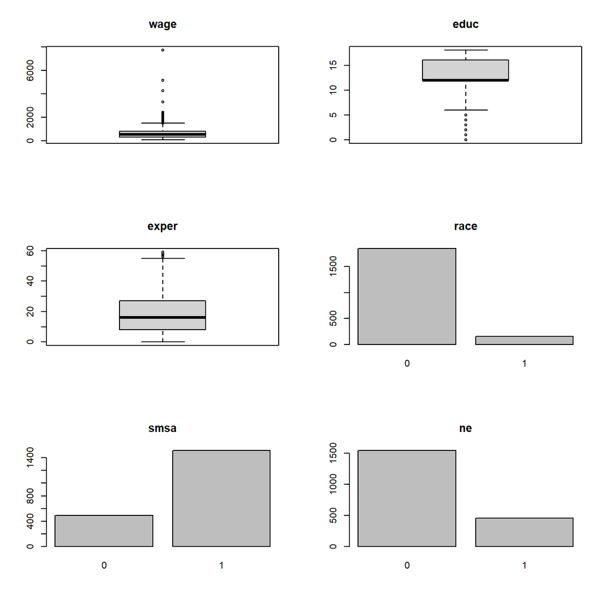

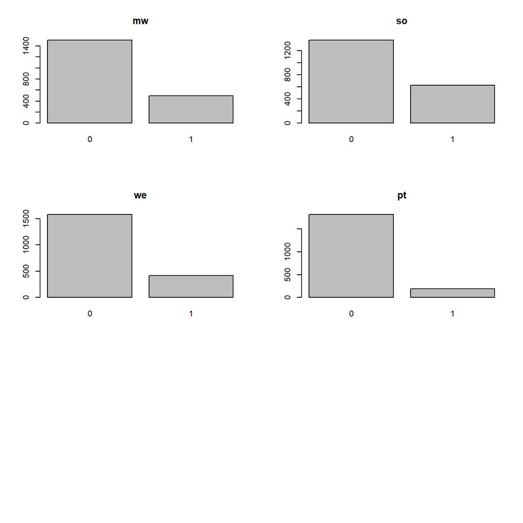

```r
> par(mfrow = c(3,2))
> for (i in 1:dim(uswages)[2]) {
+   if (class(uswages[,i]) == "factor") {try(plot(uswages[,i],
+             main =  colnames(uswages)[i]),TRUE)
+   }else {
+       try(boxplot(uswages[,i], main =colnames(uswages)[i]),TRUE)
+   }
+ }
```

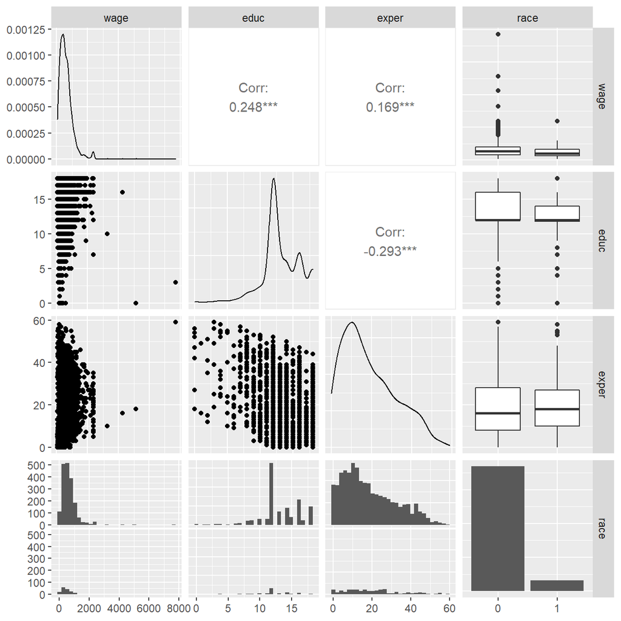

```r
> require(ggplot2)
> require(GGally)
> ggpairs(uswages[1:4])
```

### Ejercicio 3

**The dataset prostate is from a study on 97 men with prostate cancer who were due to receive a radical prostatectomy. Make a numerical and graphical summary of the data as in the ﬁrst question.**

```r
> data("prostate",package="faraway")
> # ?prostate
> head(prostate)
```

| lcavol | lweight | age | lbph | svi | lcp | gleason | pgg45 | lpsa |
| --- | --- | --- | --- | --- | --- | --- | --- | --- |
| -0.5798185 | 2.7695 | 50 | -1.386294 | 0 | -1.38629 | 6 | 0 | -0.43078 |
| -0.9942523 | 3.3196 | 58 | -1.386294 | 0 | -1.38629 | 6 | 0 | -0.16252 |
| -0.5108256 | 2.6912 | 74 | -1.386294 | 0 | -1.38629 | 7 | 20 | -0.16252 |
| -1.2039728 | 3.2828 | 58 | -1.386294 | 0 | -1.38629 | 6 | 0 | -0.16252 |
| 0.7514161 | 3.4324 | 62 | -1.386294 | 0 | -1.38629 | 6 | 0 | 0.37156 |
| -1.0498221 | 3.2288 | 50 | -1.386294 | 0 | -1.38629 | 6 | 0 | 0.76547 |

```r
> str(prostate)
```

```
'data.frame':   97 obs. of  9 variables:
 $ lcavol : num  -0.58 -0.994 -0.511 -1.204 0.751 ...
 $ lweight: num  2.77 3.32 2.69 3.28 3.43 ...
 $ age    : int  50 58 74 58 62 50 64 58 47 63 ...
 $ lbph   : num  -1.39 -1.39 -1.39 -1.39 -1.39 ...
 $ svi    : int  0 0 0 0 0 0 0 0 0 0 ...
 $ lcp    : num  -1.39 -1.39 -1.39 -1.39 -1.39 ...
 $ gleason: int  6 6 7 6 6 6 6 6 6 6 ...
 $ pgg45  : int  0 0 20 0 0 0 0 0 0 0 ...
 $ lpsa   : num  -0.431 -0.163 -0.163 -0.163 0.372 ...
```

```r
> apply(prostate, 2, class)
```

```
   lcavol   lweight       age      lbph       svi       lcp   gleason     pgg45
"numeric" "numeric" "numeric" "numeric" "numeric" "numeric" "numeric" "numeric"
     lpsa
"numeric"
```

```r
> prostate$svi <- as.factor(prostate$svi)
```

```r
> res <- compareGroups(~., data = prostate)
> restab <- createTable(res)
> restab
```

```
--------Summary descriptives table ---------

_______________________
           [ALL]     N
            N=97
¯¯¯¯¯¯¯¯¯¯¯¯¯¯¯¯¯¯¯¯¯¯¯
lcavol  1.35 (1.18)  97
lweight 3.65 (0.50)  97
age     63.9 (7.45)  97
lbph    0.10 (1.45)  97
svi:                 97
    0    76 (78.4%)
    1    21 (21.6%)
lcp     -0.18 (1.40) 97
gleason 6.75 (0.72)  97
pgg45   24.4 (28.2)  97
lpsa    2.48 (1.15)  97
¯¯¯¯¯¯¯¯¯¯¯¯¯¯¯¯¯¯¯¯¯¯¯
```

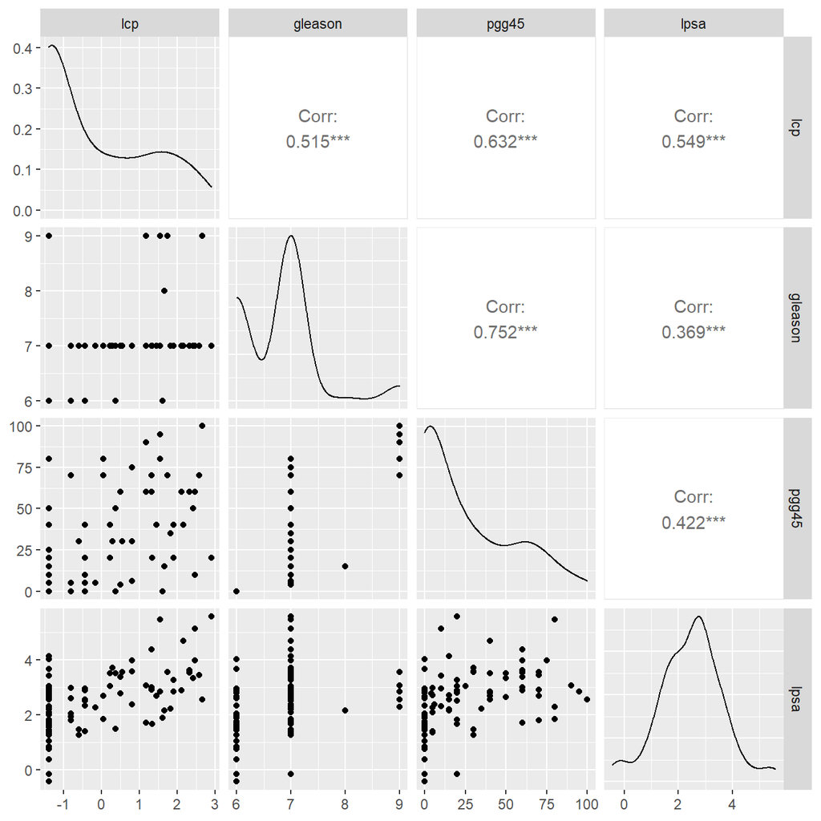

```r
> require(ggplot2)
> require(GGally)
> ggpairs(prostate[6:ncol(prostate)])
```

### Ejercicio 4

**The dataset sat comes from a study entitled “Getting What You Pay For: The Debate Over Equity in Public School Expenditures.” Make a numerical and graphical summary of the data as in the ﬁrst question.**

```r
> data("sat", package="faraway")
> head(sat)
```

|  | expend | ratio | salary | takers | verbal | math | total |
| --- | --- | --- | --- | --- | --- | --- | --- |
| Alabama | 4.405 | 17.2 | 31.144 | 8 | 491 | 538 | 1029 |
| Alaska | 8.963 | 17.6 | 47.951 | 47 | 445 | 489 | 934 |
| Arizona | 4.778 | 19.3 | 32.175 | 27 | 448 | 496 | 944 |
| Arkansas | 4.459 | 17.1 | 28.934 | 6 | 482 | 523 | 1005 |
| California | 4.992 | 24.0 | 41.078 | 45 | 417 | 485 | 902 |
| Colorado | 5.443 | 18.4 | 34.571 | 29 | 462 | 518 | 980 |

```r
> res <- compareGroups(~., data = sat)
> restab <- createTable(res)
> restab
```

```
--------Summary descriptives table ---------

_____________________
          [ALL]    N
          N=50
¯¯¯¯¯¯¯¯¯¯¯¯¯¯¯¯¯¯¯¯¯
expend 5.91 (1.36) 50
ratio  16.9 (2.27) 50
salary 34.8 (5.94) 50
takers 35.2 (26.8) 50
verbal 457 (35.2)  50
math   509 (40.2)  50
total  966 (74.8)  50
¯¯¯¯¯¯¯¯¯¯¯¯¯¯¯¯¯¯¯¯¯
```

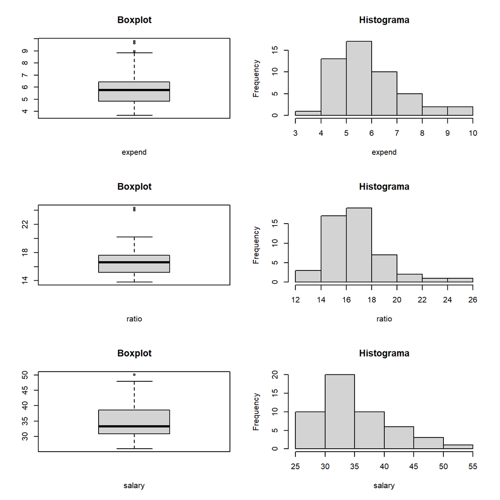

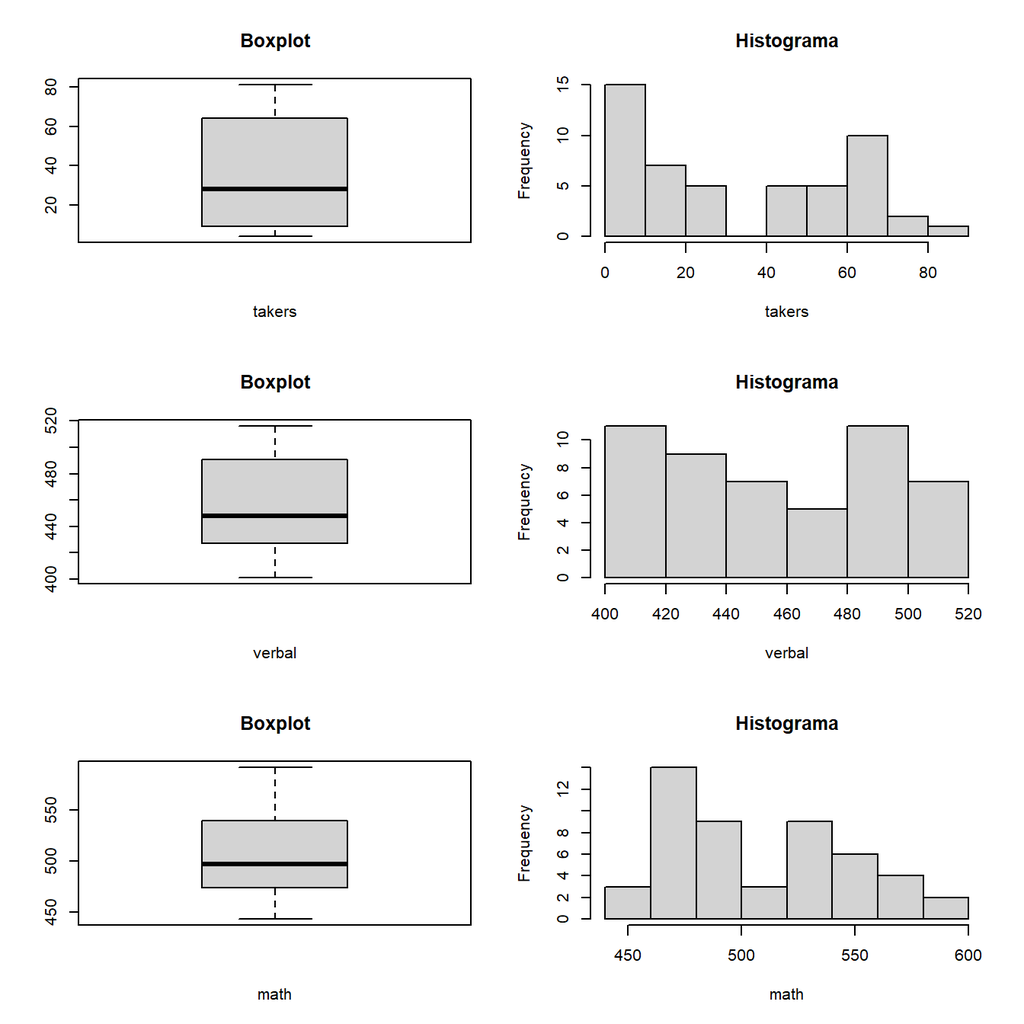

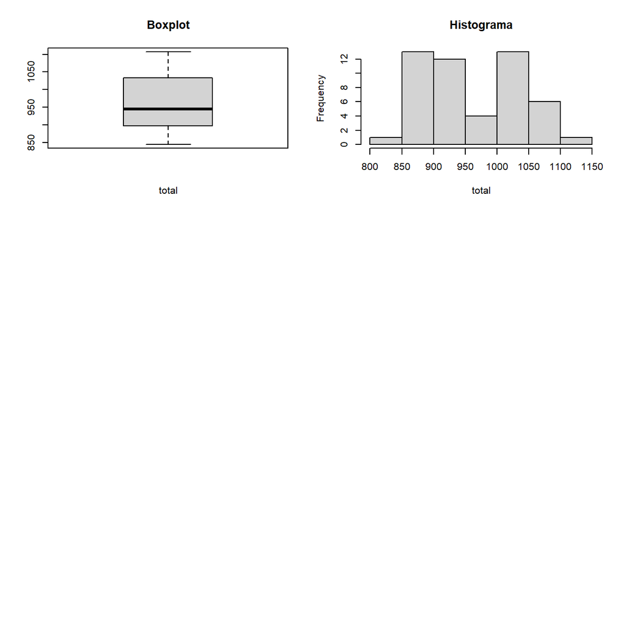

```r
> par(mfrow = c(3,2))
> for (i in 1:dim(sat)[2]) {
+   if (class(sat[,i]) == "factor") {try(plot(sat[,i], xlab = names(sat)[i], main = "Diagrama de cajas"),TRUE)
+   }else {
+       try(boxplot(sat[,i], xlab = names(sat)[i], main = "Boxplot"),TRUE)
+     try(hist(sat[,i], xlab = names(sat)[i], main = "Histograma"),TRUE)
+   }
+ }
```

### Ejercicio 5

**The dataset `divusa` contains data on divorces in the United States from 1920 to 1996. Make a numerical and graphical summary of the data as in the ﬁrst question.**

```r
> data("divusa",package="faraway")
> # ?divusa
> head(divusa)
```

| year | divorce | unemployed | femlab | marriage | birth | military |
| --- | --- | --- | --- | --- | --- | --- |
| 1920 | 8.0 | 5.2 | 22.70 | 92.0 | 117.9 | 3.2247 |
| 1921 | 7.2 | 11.7 | 22.79 | 83.0 | 119.8 | 3.5614 |
| 1922 | 6.6 | 6.7 | 22.88 | 79.7 | 111.2 | 2.4553 |
| 1923 | 7.1 | 2.4 | 22.97 | 85.2 | 110.5 | 2.2065 |
| 1924 | 7.2 | 5.0 | 23.06 | 80.3 | 110.9 | 2.2889 |
| 1925 | 7.2 | 3.2 | 23.15 | 79.2 | 106.6 | 2.1735 |

```r
> str(divusa)
```

```
'data.frame':   77 obs. of  7 variables:
 $ year      : int  1920 1921 1922 1923 1924 1925 1926 1927 1928 1929 ...
 $ divorce   : num  8 7.2 6.6 7.1 7.2 7.2 7.5 7.8 7.8 8 ...
 $ unemployed: num  5.2 11.7 6.7 2.4 5 3.2 1.8 3.3 4.2 3.2 ...
 $ femlab    : num  22.7 22.8 22.9 23 23.1 ...
 $ marriage  : num  92 83 79.7 85.2 80.3 79.2 78.7 77 74.1 75.5 ...
 $ birth     : num  118 120 111 110 111 ...
 $ military  : num  3.22 3.56 2.46 2.21 2.29 ...
```

```r
> res <- compareGroups(~., data = divusa)
> restab <- createTable(res)
> restab
```

```
--------Summary descriptives table ---------

_________________________
              [ALL]    N
              N=77
¯¯¯¯¯¯¯¯¯¯¯¯¯¯¯¯¯¯¯¯¯¯¯¯¯
year       1958 (22.4) 77
divorce    13.3 (5.67) 77
unemployed 7.17 (5.08) 77
femlab     38.6 (11.8) 77
marriage   73.0 (13.1) 77
birth      88.9 (19.5) 77
military   12.4 (14.9) 77
¯¯¯¯¯¯¯¯¯¯¯¯¯¯¯¯¯¯¯¯¯¯¯¯¯
```

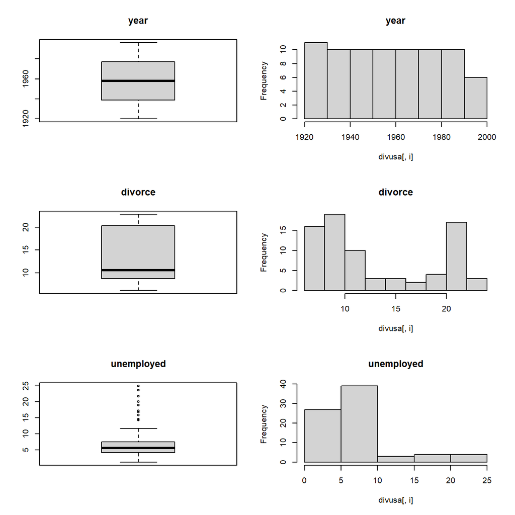

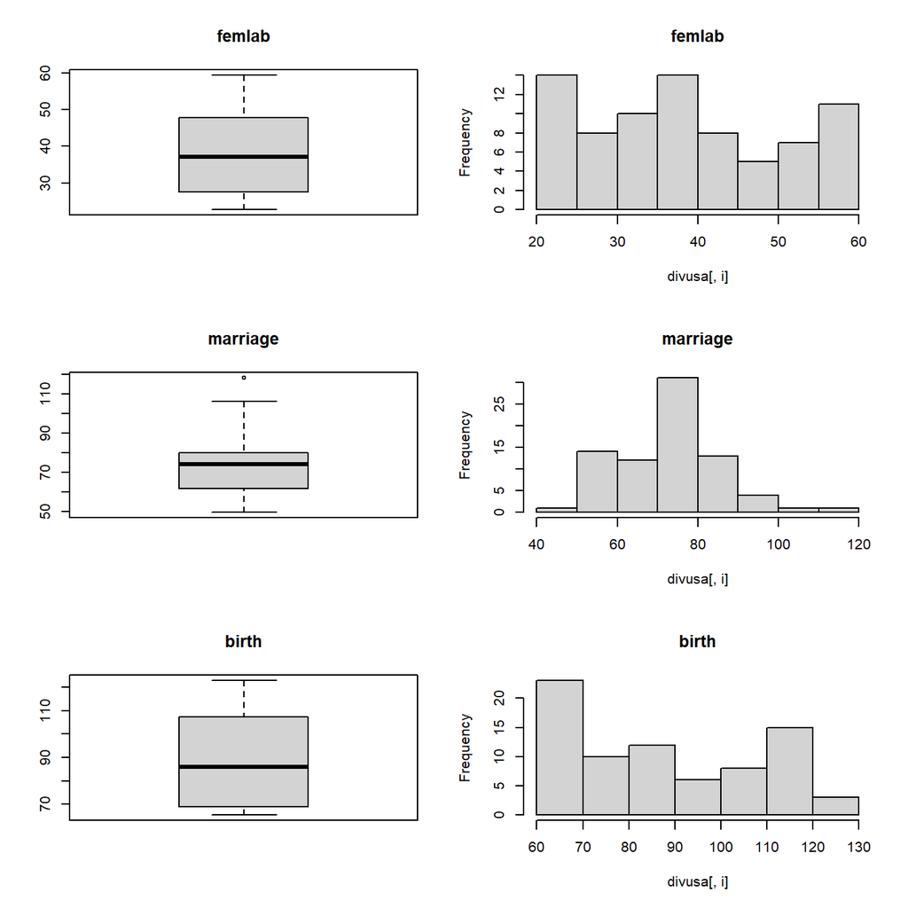

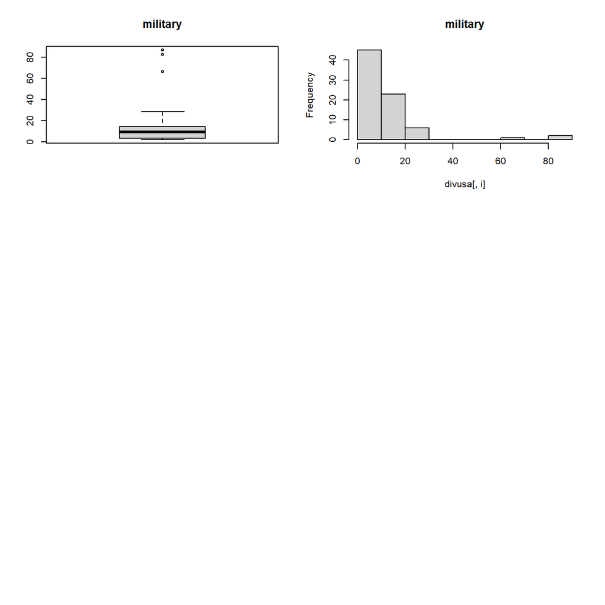

```r
> par(mfrow = c(3,2))
> for (i in 1:dim(divusa)[2]) {
+   if (class(divusa[,i]) == "factor") {try(plot(divusa[,i], main = names(divusa)[i]),TRUE)
+   }else {
+       try(boxplot(divusa[,i],  main =names(divusa)[i]),TRUE)
+       try(hist(divusa[,i], main = names(divusa)[i]),TRUE)
+   }
+ }
```

# Ejercicios de libro de Carmona

## Capítulo 1

### Ejercicio 1.3

**Consideremos el problema de tráfico planteado en el apartado 1.2 de este capítulo, con la variable independiente densidad y la variable dependiente raíz cuadrada de la velocidad. Con los datos proporcionados en la tabla 1.1 realizar el siguiente proceso:**

1. **Dibujar la nube de puntos y la recta que pasa por los puntos $(12.7, \sqrt{62.4})$ y $(87.8, \sqrt{12.4})$. Dibujar el gráﬁco de los residuos con la densidad y el gráﬁco con las predicciones. Calcular la suma de cuadrados de los residuos.**

```r
> densidad <- c(12.7,17,66,50,87.8,81.4,75.6,66.2,81.1,62.8,77,89.6,18.3,19.1,16.5,22.2,18.6,66,60.3,56,66.3,61.7,66.6,67.8)
> velocidad <- c(62.4,50.7,17.1,25.9,12.4,13.4,13.7,17.9,13.8,17.9,15.8,12.6,51.2,50.8 ,54.7,46.5,46.3,16.9,19.8,21.2,18.3,18,16.6,18.3)
> rvelocidad <- sqrt(velocidad)
```

Calculamos la recta que pasa por los puntos $(12.7, \sqrt{62.4})$ y $(87.8, \sqrt{12.4})$ y la dibujamos en el gráﬁco. Como solo tenemos dos puntos, la recta de ajuste mínimo-cuadrático coincide con la recta que pasa por esos puntos.

Vamos a usar la fucnión `lsﬁt()` (least squares ﬁt) que devuelve un objeto que contiene:

- los estimadores de los parámetros,
- residuos
- factorización QR.

En general es mejor utilizar la función `lm()` (linear model).

```r
> x <- c(12.7, 87.8)
> y <- sqrt(c(62.4,12.4))
> slope <- diff(y)/diff(x)
> intercept <- y[1]-slope*x[1]
> c(intercept, slope)
```

```
[1]  8.63972188 -0.05829566
```

```r
> recta.vel <- lsfit(x,y)
> coef(recta.vel)
```

```
  Intercept           X
 8.63972188 -0.05829566
```

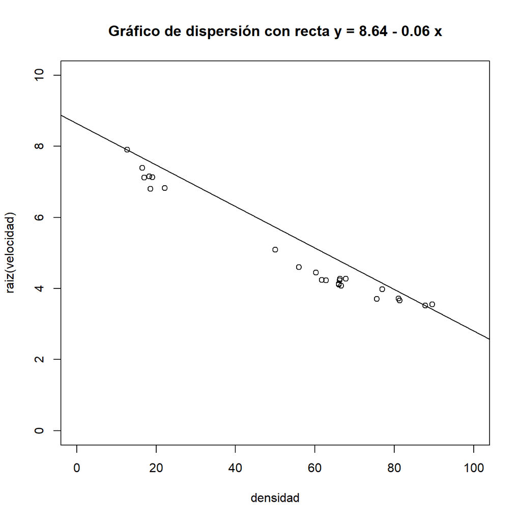

```r
> # recta.vel
> plot(densidad, rvelocidad, type="p", xlab ="densidad", ylab="raiz(velocidad)",
+      xlim=c(0 ,100), ylim=c(0,10),main="Gráfico de dispersión con recta y = 8.64 - 0.06 x")
> # abline(intercept, slope)
> abline(recta.vel)
```

El siguiente paso es calcular los residuos y las predicciones si utilizamos esta recta.

```r
> predicciones <- recta.vel$coef[1] + recta.vel$coef[2] * densidad
> residuos <- rvelocidad - predicciones
```

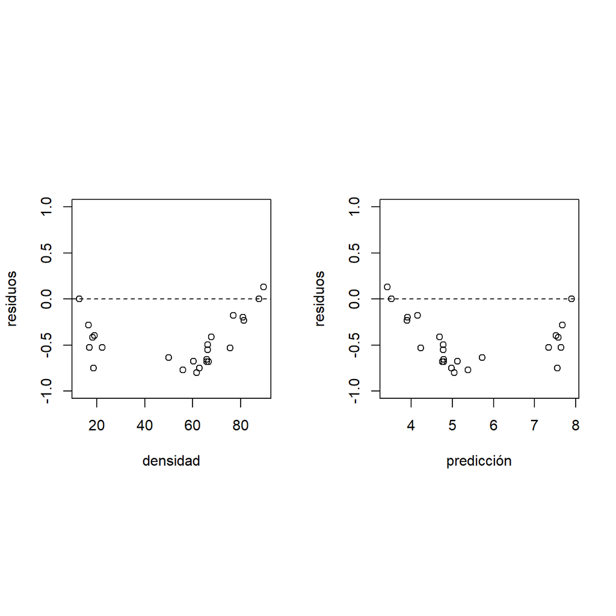

```r
> par(mfrow=c(1,2))
> par(pty="s")
> plot(densidad,residuos,xlab="densidad",ylab="residuos", ylim=c(-1,1))
> abline(h=0, lty=2)
>
> plot(predicciones,residuos,xlab="predicción",ylab="residuos", ylim=c(-1,1))
> abline(h=0, lty=2)
```

La suma de cuadrados de los residuos es: 6.6898355.

2. **Hallar la recta de regresión simple. Dibujar el gráﬁco de los residuos con la densidad y el gráﬁco con las predicciones. Calcular la suma de cuadrados de los residuos.**

```r
> recta.velocidad <- lsfit(densidad,rvelocidad)
> e <- recta.velocidad$residuals
> pred <- rvelocidad - e
```

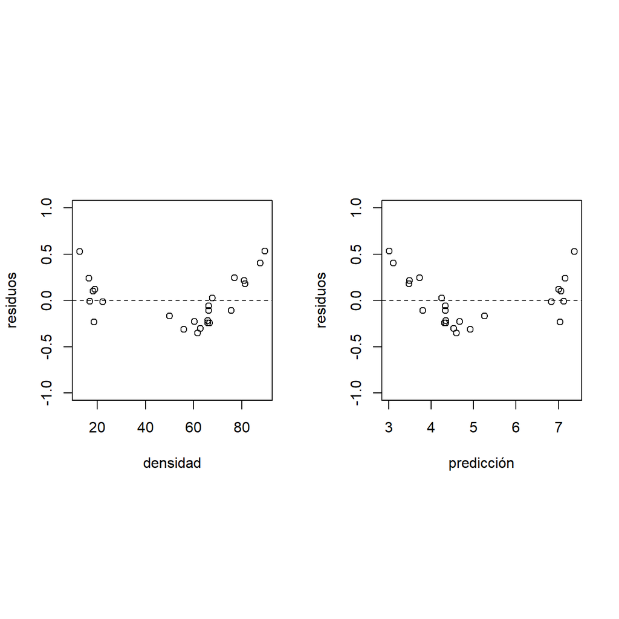

```r
> par(mfrow=c(1,2))
> par(pty="s")
> plot(densidad,e,xlab="densidad",ylab="residuos", ylim=c(-1,1))
> abline(h=0, lty=2)
>
> plot(pred,e,xlab="predicción",ylab="residuos", ylim=c(-1,1))
> abline(h=0, lty=2)
```

La suma de cuadrados de los residuos es: 1.5912177.

c.**Mejorar el modelo anterior considerando una regresión parabólica. Dibujar el gráﬁco de los residuos con la densidad y el gráﬁco con las predicciones. Calcular la suma de cuadrados de los residuos.**

```r
> matriz.densidad <- as.matrix(data.frame(densidad, densidad^2))
> parabola.ls <- lsfit(matriz.densidad,rvelocidad)
> parabola.ls$coef
```

```
    Intercept      densidad    densidad.2
 8.8814208199 -0.1035152795  0.0004892585
```

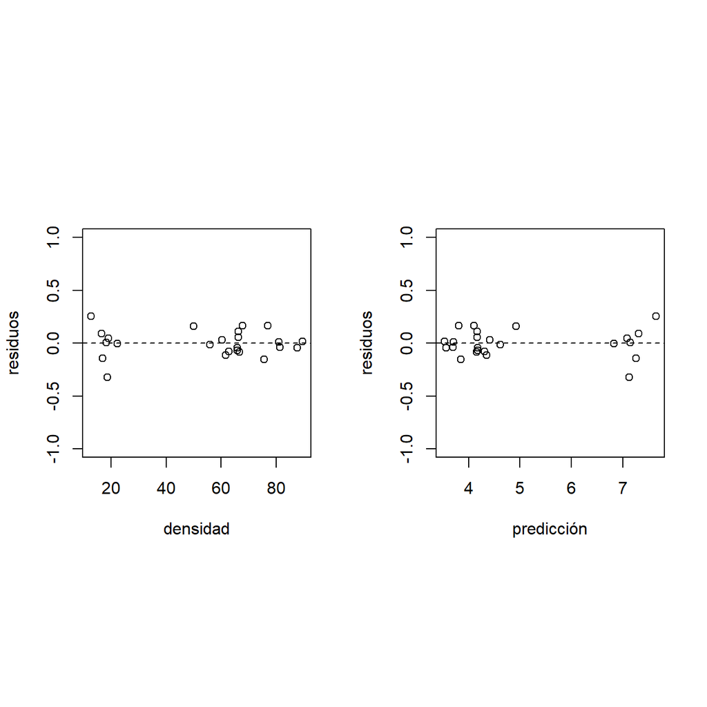

```r
> e<-parabola.ls$residuals
> par(mfrow=c(1,2))
> par(pty="s")
> plot(densidad,e,xlab="densidad",ylab="residuos",ylim=c(-1,1))
> abline(h=0, lty=2)
> pred<-rvelocidad-e
> plot(pred,e,type="p",xlab="predicción",ylab="residuos",ylim=c(-1,1))
> abline(h=0, lty=2)
```

La suma de cuadrados de los residuos es: 0.3534143.

4. **Calcular la capacidad de la carretera o punto de máximo ﬂujo. Recordar que ﬂujo = vel $\times$ densidad.**

Como hemos hallado una relación parabólica entre la raíz de la velocidad y la densidad, vamos a utilizar esta relación en el cálculo del flujo.

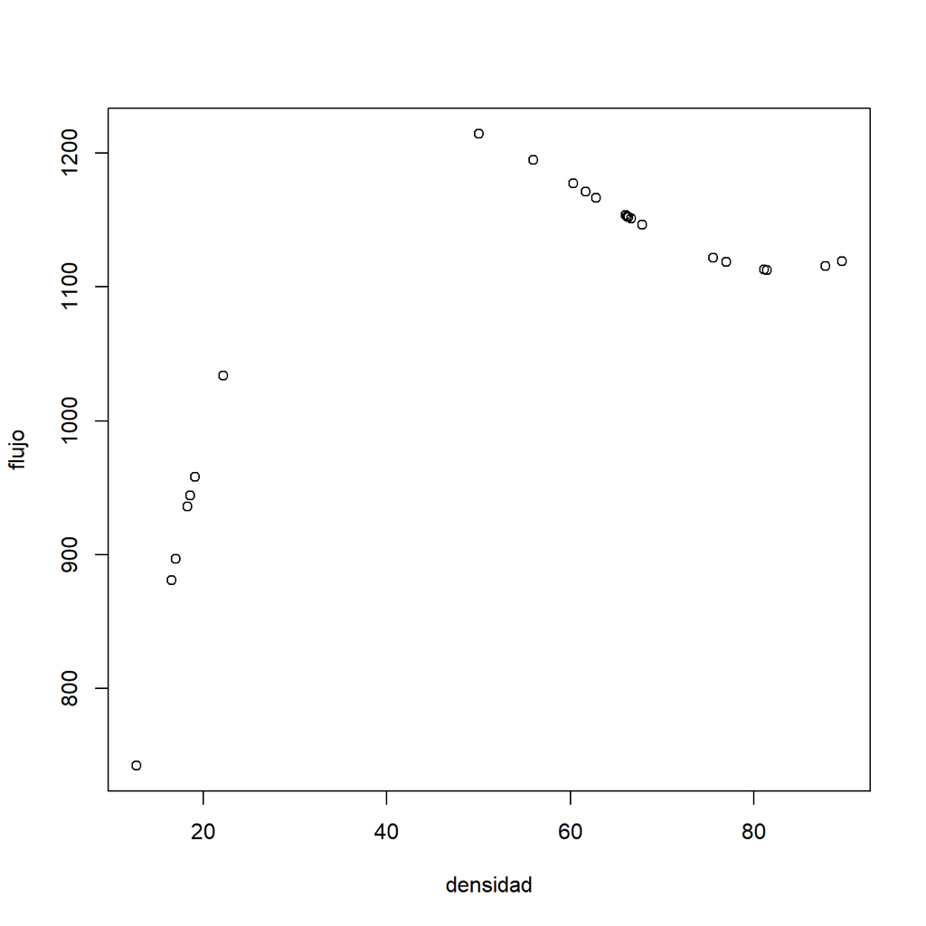

```r
> cc <- parabola.ls$coefficients
> flujo <- (cc[1] + cc[2]*densidad + cc[3] * densidad^2)^2 * densidad
> plot(densidad,flujo)
```

El máximo flujo es 1214.6550191 y se produce con una densidad de: 50.

Como el flujo es una función polinómica de la densidad, también se puede derivar la función y hallar el máximo.

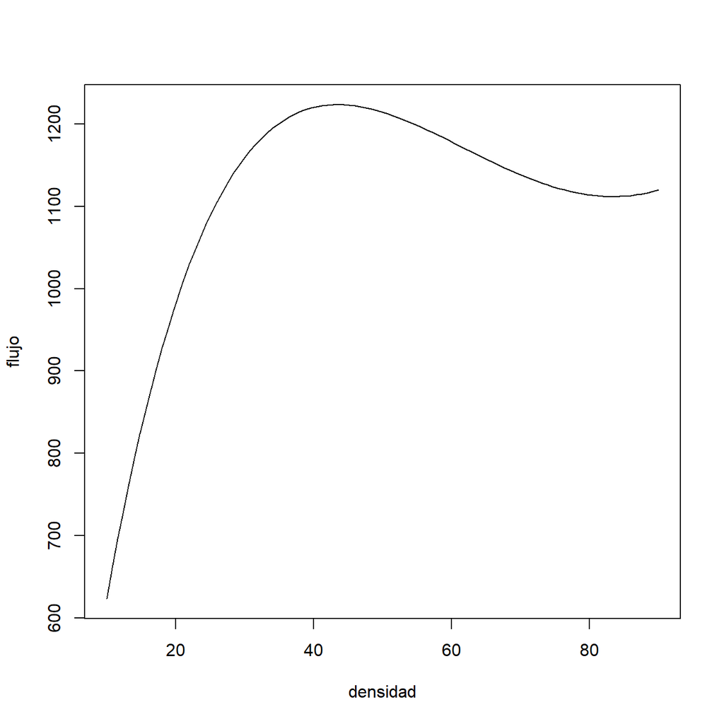

```r
> f <- function(x) (8.8814208199 -0.1035152795*x + 0.0004892585*x^2)^2 * x
> curve(f, 10, 90, ylab="flujo", xlab="densidad")
```

La derivada es

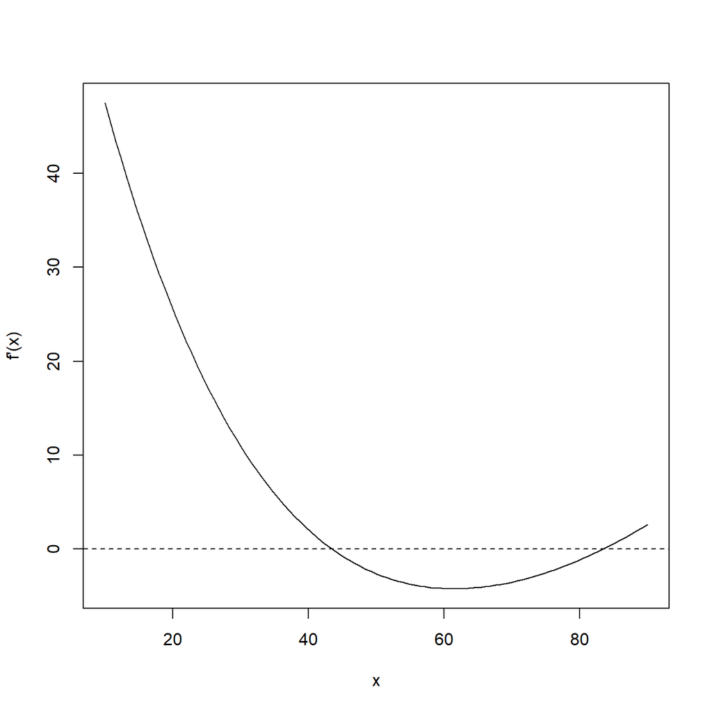

```r
> # base package
> # d <- D(body(f), "x")
> # fd <- function(x) {}
> # body(fd) <- d
> #
> # with mosaicCalc
> library(mosaicCalc)
> fd <- D(f(x) ~ x)
> curve(fd(x), 10, 90, ylab="f'(x)")
> abline(h=0, lty=2)
```

Para calcular el máximo, buscaremos el cero de la derivada.

```r
> library(rootSolve)
> roots <- multiroot(fd, c(40,90))
> print(roots$root)
```

```
[1] 43.51714 83.42837
```

La solución de un flujo máximo se produce con una densidad de 43.5171355.

### Ejercicio 1.4

**La siguiente tabla contiene los mejores tiempos conseguidos en algunas pruebas de velocidad en atletismo en los Juegos Olímpicos de Atlanta. Si tomamos como variable regresora o independiente la distancia (metros) y como variable respuesta o dependiente el tiempo (segundos):**

1. **Calcular la recta de regresión simple con los datos de los hombres y dibujarla. Dibujar el gráﬁco de los residuos con la distancia y el gráﬁco con las predicciones. Calcular la suma de cuadrados de los residuos y el $R^2$**

```r
> TPO_H <- c(9.84,19.32,43.19,102.58,215.78,787.96,1627.34,7956)
> TPO_M <- c(10.94,22.12,48.25,117.73,240.83,899.88,1861.63,8765)
> distancia <- c(100,200,400,800,1500,5000,10000,42192)
> juegos <- data.frame(distancia,TPO_H,TPO_M)
> #summary(juegos)
> recta.tpo_h <- lsfit(distancia,TPO_H)
> recta.tpo_h$coef
```

```
  Intercept           X
-78.2342453   0.1891926
```

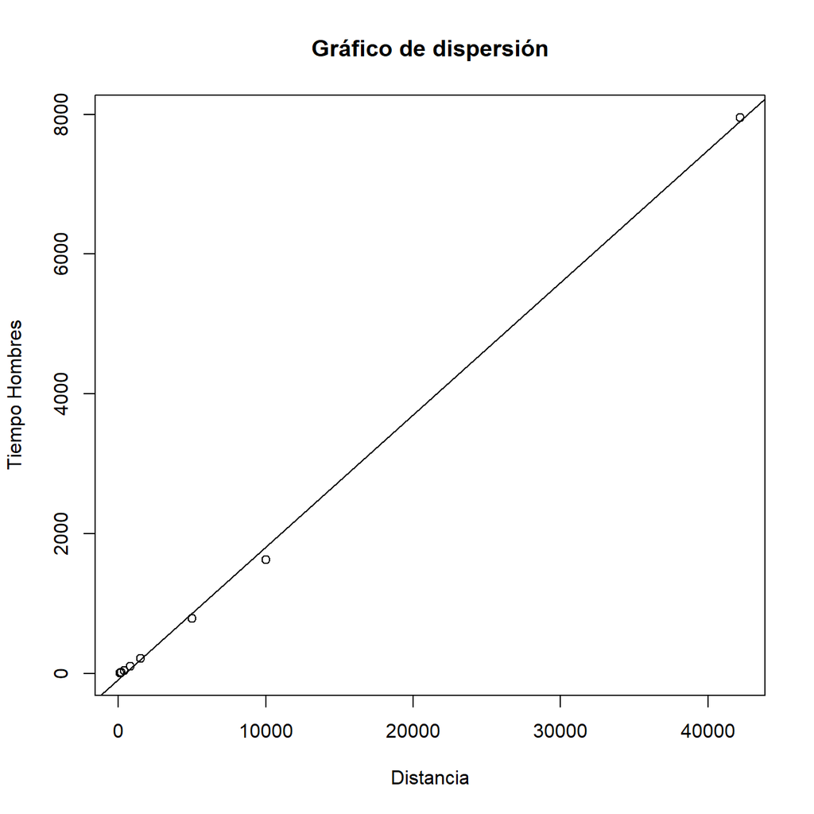

```r
> plot(distancia, TPO_H, xlab = "Distancia", ylab="Tiempo Hombres",
+      main="Gráfico de dispersión")
> abline(recta.tpo_h)
```

$$TPO_H =−78.2342453+0.1891926\times
distancia$$

Dibujamos gráﬁco de residuos con la distancia y el gráﬁco con las predicciones

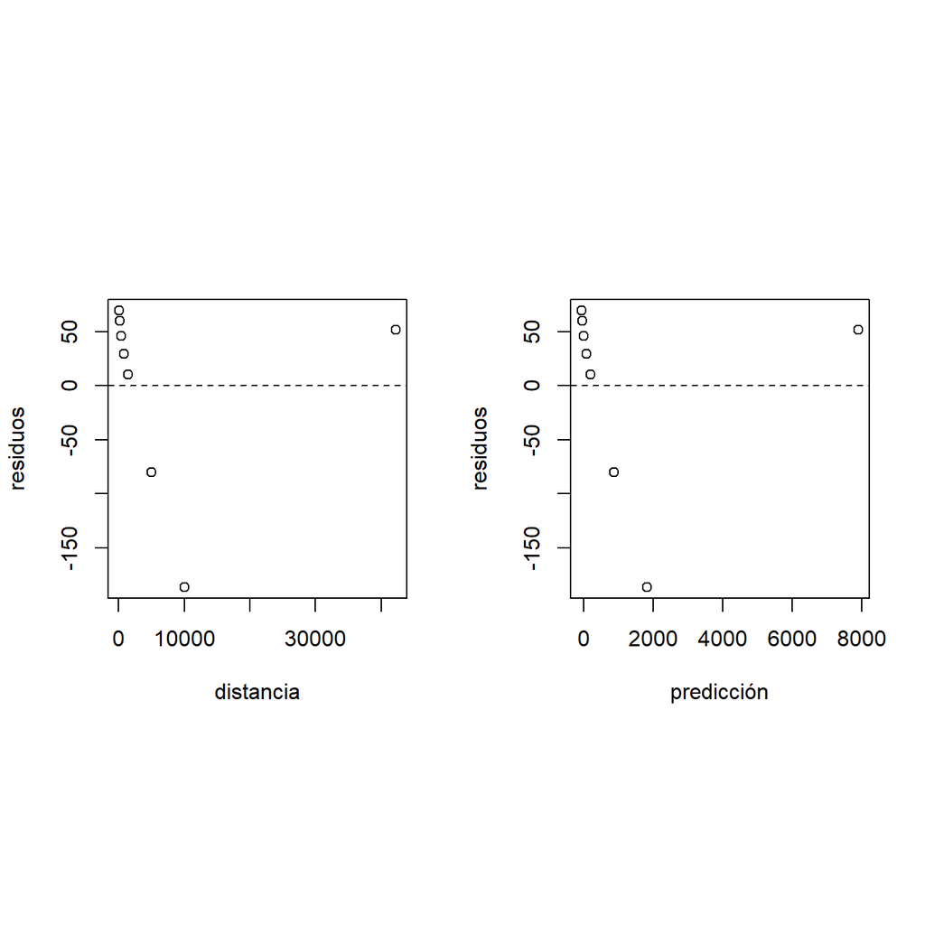

```r
> e<-recta.tpo_h$residuals
> pred<-TPO_H-e
> par(mfrow=c(1,2), pty="s")
> plot(distancia,e,xlab="distancia",ylab="residuos")
> abline(h=0, lty=2)
> plot(pred,e,xlab="predicción",ylab="residuos")
> abline(h=0, lty=2)
```

La suma de cuadrados de los residuos es 55189.

```r
> ls.print(recta.tpo_h, digits=4, print.it=T)
```

```
Residual Standard Error=95.9071
R-Square=0.9989
F-statistic (df=1, 6)=5663.485
p-value=0

          Estimate Std.Err t-value Pr(>|t|)
Intercept -78.2342 38.8273 -2.0149   0.0905
X           0.1892  0.0025 75.2561   0.0000
```

```r
> cat("R2:  0.9989")
```

```
R2:  0.9989
```

b.**Repetir el apartado anterior utilizando los logaritmos de las variables tiempo y distancia.**

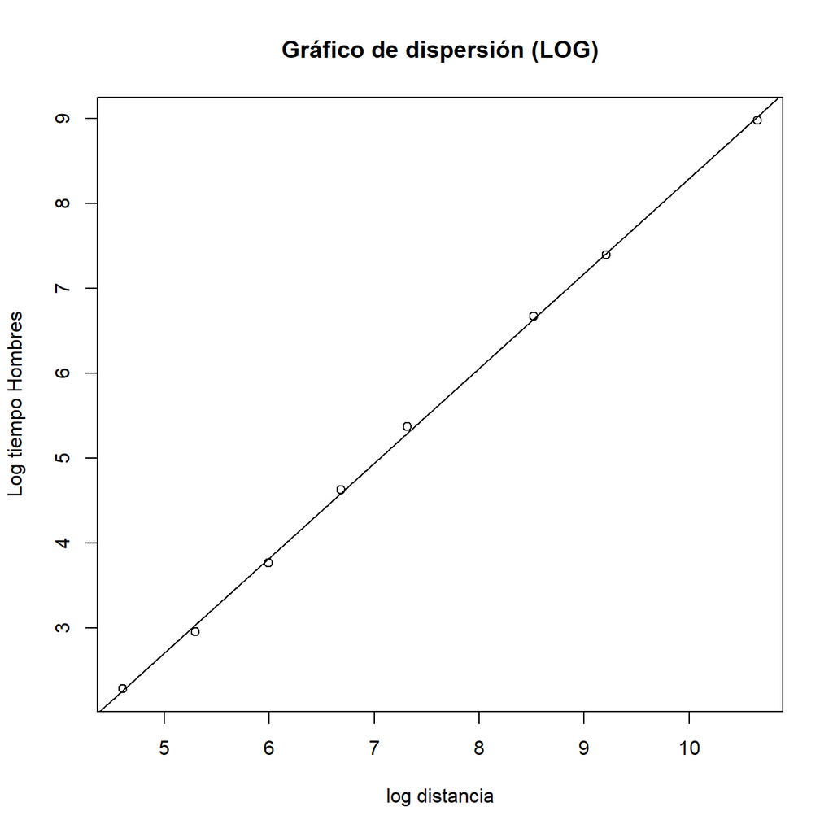

```r
> ldistancia <- log(distancia)
> lTPO_H <- log(TPO_H)
> lrecta.tpo_h <- lsfit(ldistancia,lTPO_H)
> plot(ldistancia, lTPO_H, xlab = "log distancia", ylab="Log tiempo Hombres",
+      main ="Gráfico de dispersión (LOG)")
> abline(lrecta.tpo_h)
```

$$\log(TP_H) = −2.885964+1.118094 \times
\log(distancia)$$

Dibujamos el gráﬁco de residuos con la distancia y el gráﬁco con las predicciones.

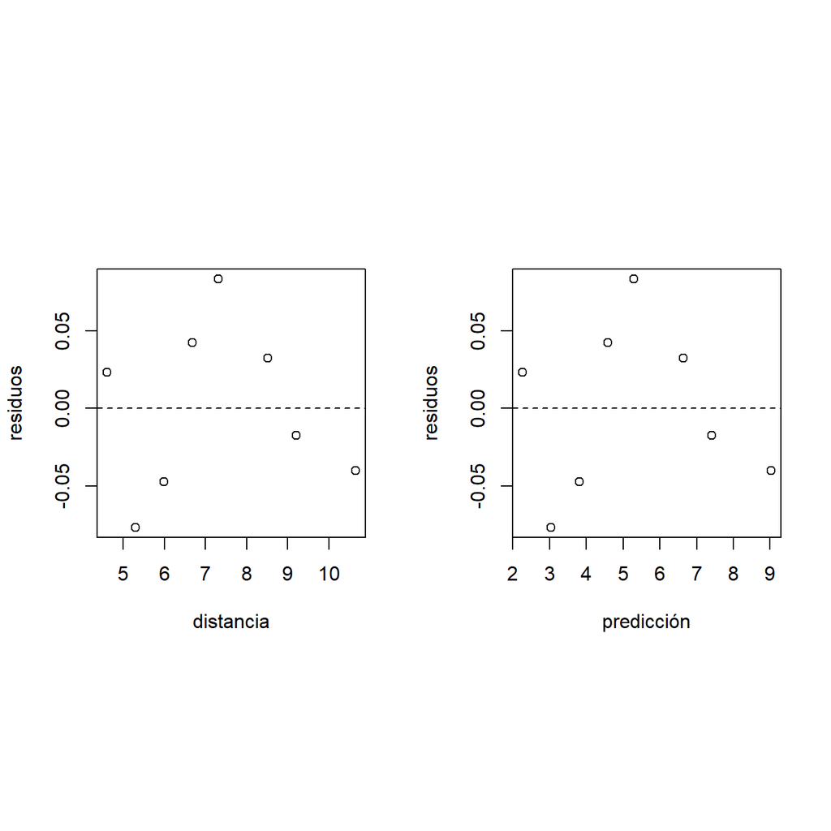

```r
> e <- lrecta.tpo_h$residuals
> par(mfrow=c(1,2), pty="s")
> plot(ldistancia,e,type="p",xlab="distancia",ylab="residuos")
> abline(h=0, lty=2)
> pred<-lTPO_H-e
> plot(pred,e,type="p",xlab="predicción",ylab="residuos")
> abline(h=0, lty=2)
```

La suma de cuadrados de los residuos es 0.0204296.

```r
> ls.print(lrecta.tpo_h,digits=4, print.it=T)
```

```
Residual Standard Error=0.0584
R-Square=0.9995
F-statistic (df=1, 6)=10908.58
p-value=0

          Estimate Std.Err  t-value Pr(>|t|)
Intercept  -2.8860  0.0807 -35.7806        0
X           1.1181  0.0107 104.4441        0
```

```r
> cat("R2:  0.9995")
```

```
R2:  0.9995
```

3. **Repetir los dos apartados anteriores utilizando los datos de las mujeres.**

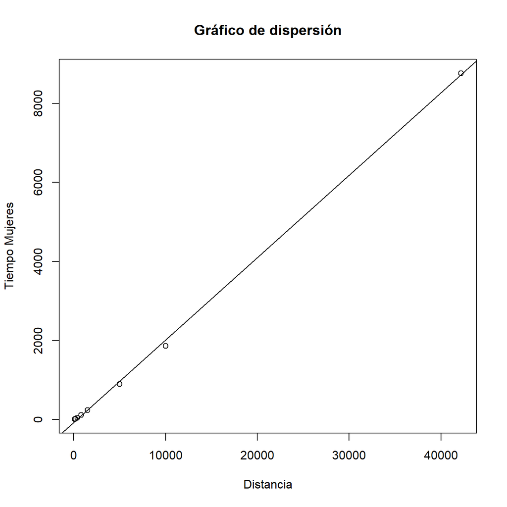

```r
> recta.tpo_m <- lsfit(distancia,TPO_M)
> plot(distancia,TPO_M,xlab = "Distancia",ylab="Tiempo Mujeres",
+      main="Gráfico de dispersión")
> abline(recta.tpo_m)
```

$TPO_M =−72.5791085+0.2084498 \times distancia$ Dibujamos gráﬁco residuos con la distancia y el gráﬁco con las predicciones.

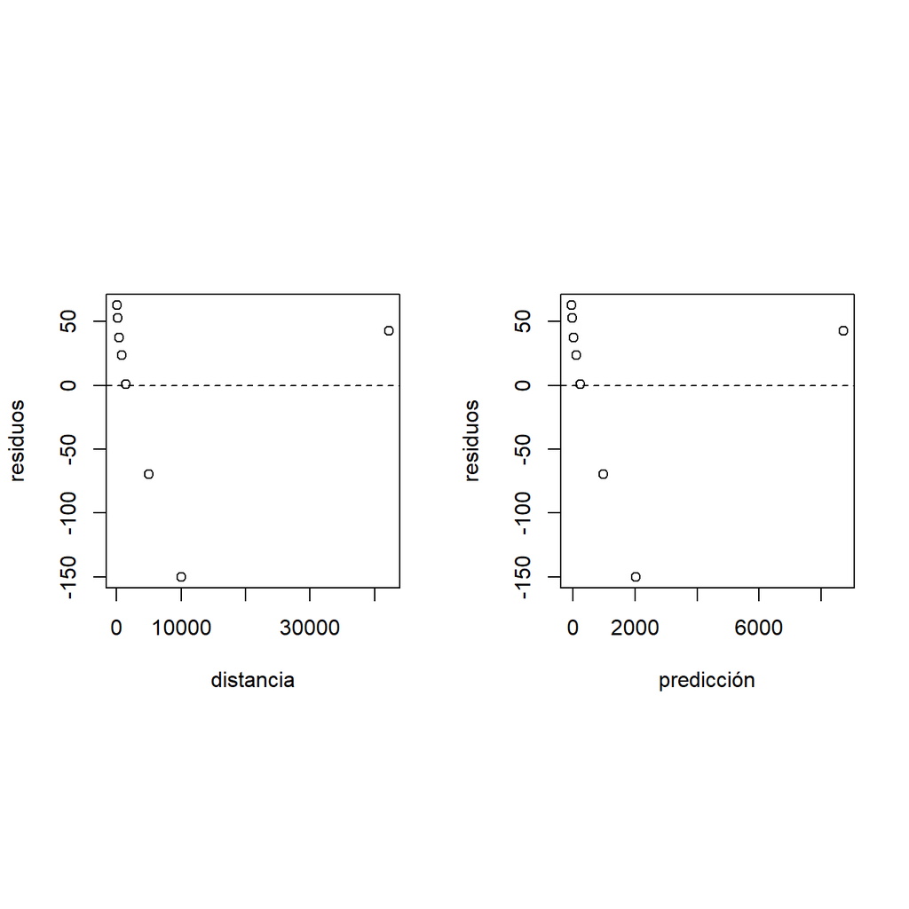

```r
> e<-recta.tpo_m$residuals
> pred<-TPO_M-e
> par(mfrow=c(1,2), pty="s")
> plot(distancia,e,xlab="distancia",ylab="residuos")
> abline(h=0, lty=2)
> plot(pred,e,xlab="predicción",ylab="residuos")
> abline(h=0, lty=2)
```